Dataset description:

```
Predict whether income exceeds $50K/yr based on census data. Also known as "Census Income" dataset. Target filed: Income
-- The income is divided into two classes: <=50K and >50K (0 and 1)
Number of attributes: 14
```

Three XGBoost classifiers were trained:

1. Large XGBoost model (150 estimators)
2. Small XGBoost model (4 estimators)
3. Reweighted Large XGboost model (reweighting bias mitigation applied to 1st model)

The variable deemed as proteced was Gender, with Male deemed the privileged option

The original model and the smaller one perform very comparably in the Fairness Check, with Equal opportunity/Predictive parity being well within norm, and Statistical parity being far out of the norm.

Statistical parity is violated: the prediction of high income is far more likely for males. This might be due to the fact that historically (and currently), females are often homemakers, which is bound to lower income, that in turn being reflected in the census data.

The reweighting technique successfully mitigated parts of bias in the two biggest metric deviations: Predictive equality ratio and Statistical parity ratiom at the cost of Equal opportunity ratio and Predictive parity (this one was slight)

The model performance does not suffer too much from reweighting, but of course there is a drop - we weigh the importance of different samples differently, so the training objective is no longer accuracy - we cannot expect the model to do as well.

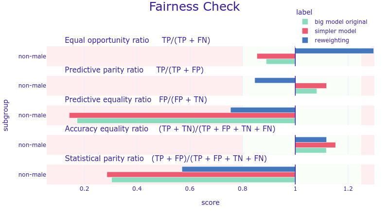

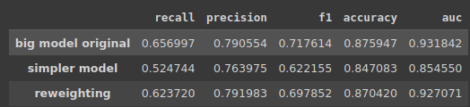